# CensusAggregator Report

[figure not shown]

[figure not shown]

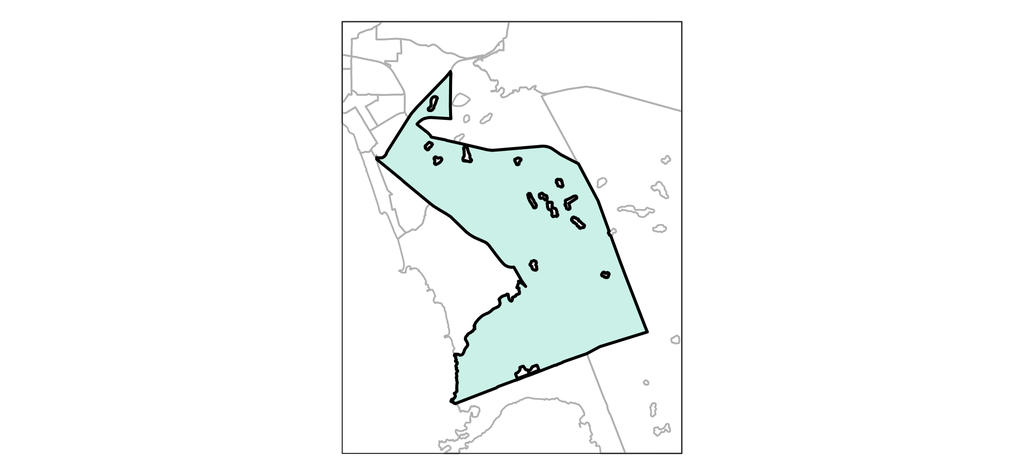

[Open in CensusAggregator](https://censusaggregator.ca/)

Population

310

Households

112

Population change  
(2016 to 2021)

+1.0%

Population density  
(people/km<sup>2</sup>)

8.6

# Age, households, and families

## Population by age cohorts

| 0 to 14 | 35 | 11.1% |  |
| --- | --- | --- | --- |
| 15 to 24 | 35 | 11.1% |  |
| 25 to 44 | 55 | 17.5% |  |
| 45 to 65 | 125 | 39.7% |  |
| 65 to 84 | 55 | 17.5% |  |
| 85+ | 5 | 1.6% |  |

## Private households by size

| 1 person | 25 | 22.7% |  |
| --- | --- | --- | --- |
| 2 persons | 50 | 45.5% |  |
| 3 persons | 15 | 13.6% |  |
| 4 persons | 10 | 9.1% |  |
| 5+ persons | 10 | 9.1% |  |

## Family type

| Couples with children | 30 | 37.5% |  |
| --- | --- | --- | --- |
| Single parent | 10 | 12.5% |  |
| Single woman+ parent | 0 | 0.0% |  |

## Household type

| 1 census family, + additional persons | 0 | 0.0% |  |
| --- | --- | --- | --- |
| 1 census family, no additional persons | 75 | 68.2% |  |
| 1 person | 30 | 27.3% |  |
| 2+ persons non census family | 5 | 4.5% |  |
| Multigen. households | 0 | 0.0% |  |
| Multiple census families | 0 | 0.0% |  |

# Language and education

Knowledge of English

Knowledge of French

30.6%

English spoken most often at home

95.2%

French spoken most often at home

3.2%

## Top non-official languages spoken most often at home

No data on non-official languages spoken most often at home.

## Educational attainment

| No high school or postsecondary | 60 | 27.9% |  |
| --- | --- | --- | --- |
| High school or equivalent | 65 | 30.2% |  |
| Postsecondary | 85 | 39.5% |  |

# Income and housing

Median household income

$84,000

Low income (LIM-AT)

9.4%

Unaffordable housing

—

*Note: — indicates data for one or more of the selected areas is not available or is suppressed due to confidentiality.*

## Total household income

| Under $20,000 | 5 | 4.5% |  |
| --- | --- | --- | --- |
| $20,000 to $40,000 | 10 | 9.1% |  |
| $40,000 to $60,000 | 15 | 13.6% |  |
| $60,000 to $80,000 | 20 | 18.2% |  |
| $80,000 to $100,000 | 5 | 4.5% |  |
| $100,000 and over | 45 | 40.9% |  |

## Average shelter cost

| Owned dwellings | $1,200 |  |
| --- | --- | --- |
| Rented dwellings | $700 |  |

## Household tenure

| Owner | 85 | 81.0% |  |
| --- | --- | --- | --- |
| Renter | 15 | 14.3% |  |
| Dwelling provided by First Nation or Indian band | 0 | 0.0% |  |

# Diversity and immigration

Visible minority

0.0%

Total immigrants

0.0%

Recent immigrants  
(2016 to 2021)

0.0%

Indigenous identity

8.5%

## Visible minority population

| Arab | 0 | 0.0% |  |
| --- | --- | --- | --- |
| Black | 0 | 0.0% |  |
| Chinese | 0 | 0.0% |  |
| Filipino | 0 | 0.0% |  |
| Japanese | 0 | 0.0% |  |
| Korean | 0 | 0.0% |  |
| Latin American | 0 | 0.0% |  |
| Multiple visible minorities | 0 | 0.0% |  |
| South Asian | 0 | 0.0% |  |
| Southeast Asian | 0 | 0.0% |  |
| Visible minority, n.i.e. | 0 | 0.0% |  |
| West Asian | 0 | 0.0% |  |

Note: "n.i.e." = not included elsewhere

## Top ethnic or cultural origins

| English | 60 | 25.5% |  |
| --- | --- | --- | --- |
| Canadian | 50 | 21.3% |  |
| Irish | 50 | 21.3% |  |
| French, n.o.s. | 50 | 21.3% |  |
| German | 50 | 21.3% |  |
| Scottish | 35 | 14.9% |  |
| Dutch | 30 | 12.8% |  |
| Polish | 20 | 8.5% |  |
| Italian | 15 | 6.4% |  |
| French Canadian | 15 | 6.4% |  |

Note: "n.o.s." = not otherwise specified

Data from CensusAggregator is adapted from Statistics Canada’s 2021 *Census of Population* and may be freely used, reproduced, published, and distributed under the [Statistics Canada Open Data Licence](https://www.statcan.gc.ca/eng/reference/licence). Statistics Canada must be acknowledged as the source when using the data; acknowledgment of CensusAggregator is optional. The geographic boundaries have undergone some processing and may differ from the boundary files originally released by Statistics Canada. To protect privacy, Statistics Canada randomly rounds to the nearest 0 or 5 – this can impact the precision of the percentages shown in CensusAggregator.

CensusAggregator was developed by [Purpose Analytics](https://purposeanalytics.ca) in collaboration with [Sharla Gelfand](https://sharla.online) and Mountain Math, the creator of [CensusMapper](https://censusmapper.ca).

# Definitions

[output not shown]

[output not shown]

[output not shown]

[output not shown]

# Definitions, continued

[output not shown]